# Database - Baseball

```python
import numpy as np
```

```python
import pandas as pd
```

```python
import matplotlib.pyplot as plt
```

```python
import seaborn as sns
```

```python
Salaries_filename = 'C:/users/Guhy/Salaries.csv'
AwardSharePlayers_filename = 'C:/users/Guhy/AwardSharePlayers.csv'
```

```python
# import Salaries data
Salaries_filename = 'Salaries.csv'
salariesDF = pd.read_csv(Salaries_filename)

# import Players data
AwardSharePlayers_filename = 'AwardsSharePlayers.csv'
playersDF = pd.read_csv(AwardSharePlayers_filename)

salariesDF.head()
```

|  | yearID | teamID | lgID | playerID | salary |
| --- | --- | --- | --- | --- | --- |
| 0 | 1985 | ATL | NL | barkele01 | 870000 |
| 1 | 1985 | ATL | NL | bedrost01 | 550000 |
| 2 | 1985 | ATL | NL | benedbr01 | 545000 |
| 3 | 1985 | ATL | NL | campri01 | 633333 |
| 4 | 1985 | ATL | NL | ceronri01 | 625000 |

```python
playersDF.head()
```

|  | awardID | yearID | lgID | playerID | pointsWon | pointsMax | votesFirst |
| --- | --- | --- | --- | --- | --- | --- | --- |
| 0 | Cy Young | 1956 | ML | fordwh01 | 1.0 | 16 | 1.0 |
| 1 | Cy Young | 1956 | ML | maglisa01 | 4.0 | 16 | 4.0 |
| 2 | Cy Young | 1956 | ML | newcodo01 | 10.0 | 16 | 10.0 |
| 3 | Cy Young | 1956 | ML | spahnwa01 | 1.0 | 16 | 1.0 |
| 4 | Cy Young | 1957 | ML | donovdi01 | 1.0 | 16 | 1.0 |

Checking, is there any null value in the data. First salaries data.

```python
pd.isnull(salariesDF)
```

[output not shown]

26428 rows × 5 columns

```python
pd.isnull(salariesDF).sum()
```

```
yearID      0
teamID      0
lgID        0
playerID    0
salary      0
dtype: int64
```

Checking all the zeors in the columns

```python
salariesDF[salariesDF["yearID"] == 0]
```

|  | yearID | teamID | lgID | playerID | salary |
| --- | --- | --- | --- | --- | --- |

```python
salariesDF[salariesDF["teamID"] == 0]
```

|  | yearID | teamID | lgID | playerID | salary |
| --- | --- | --- | --- | --- | --- |

```python
salariesDF[salariesDF["salary"] == 0]
```

|  | yearID | teamID | lgID | playerID | salary |
| --- | --- | --- | --- | --- | --- |
| 6179 | 1993 | NYA | AL | jamesdi01 | 0 |
| 12007 | 1999 | PIT | NL | martija02 | 0 |

```python
salariesDF[salariesDF["lgID"] == 0]
```

|  | yearID | teamID | lgID | playerID | salary |
| --- | --- | --- | --- | --- | --- |

```python
salariesDF[salariesDF["playerID"] == 0]
```

|  | yearID | teamID | lgID | playerID | salary |
| --- | --- | --- | --- | --- | --- |

Seems to be there are two players with 0 salaries. Ltes investigate them

```python
salariesDF[salariesDF["playerID"] =="jamesdi01"]
```

|  | yearID | teamID | lgID | playerID | salary |
| --- | --- | --- | --- | --- | --- |
| 1302 | 1987 | ATL | NL | jamesdi01 | 120000 |
| 1929 | 1988 | ATL | NL | jamesdi01 | 360000 |
| 2591 | 1989 | ATL | NL | jamesdi01 | 400000 |
| 3536 | 1990 | CLE | AL | jamesdi01 | 650000 |
| 5293 | 1992 | NYA | AL | jamesdi01 | 387500 |
| 6179 | 1993 | NYA | AL | jamesdi01 | 0 |
| 8019 | 1995 | NYA | AL | jamesdi01 | 350000 |

It seems to be there is some missing data. let us assume that james salary in the year 1993 is the average of the year 1992 and 1995.

```python
salariesDF["salary"].iloc[6179] = (387500 + 350000) / 2
salariesDF[salariesDF["playerID"] == "jamesdi01"]

# Taken the average of above and below salary
```

|  | yearID | teamID | lgID | playerID | salary |
| --- | --- | --- | --- | --- | --- |
| 1302 | 1987 | ATL | NL | jamesdi01 | 120000 |
| 1929 | 1988 | ATL | NL | jamesdi01 | 360000 |
| 2591 | 1989 | ATL | NL | jamesdi01 | 400000 |
| 3536 | 1990 | CLE | AL | jamesdi01 | 650000 |
| 5293 | 1992 | NYA | AL | jamesdi01 | 387500 |
| 6179 | 1993 | NYA | AL | jamesdi01 | 368750 |
| 8019 | 1995 | NYA | AL | jamesdi01 | 350000 |

```python
# Checking for Martija02

salariesDF[salariesDF["playerID"] =="martija02"]
```

|  | yearID | teamID | lgID | playerID | salary |
| --- | --- | --- | --- | --- | --- |
| 11011 | 1998 | PIT | NL | martija02 | 170000 |
| 12007 | 1999 | PIT | NL | martija02 | 0 |

Since the data volume is low, hence let us ignore these columns

```python
salariesDF = salariesDF[salariesDF["playerID"] != "martija02"]
```

```python
salariesDF.describe()
```

|  | yearID | salary |
| --- | --- | --- |
| count | 26426.000000 | 2.642600e+04 |
| mean | 2000.878907 | 2.085799e+06 |
| std | 8.909626 | 3.455427e+06 |
| min | 1985.000000 | 1.090000e+04 |
| 25% | 1994.000000 | 2.950000e+05 |
| 50% | 2001.000000 | 5.500000e+05 |
| 75% | 2009.000000 | 2.350000e+06 |
| max | 2016.000000 | 3.300000e+07 |

Now checking with AwardsShareData

```python
# checking null values

pd.isnull(playersDF).sum()
```

```
awardID         0
yearID          0
lgID            0
playerID        0
pointsWon       0
pointsMax       0
votesFirst    358
dtype: int64
```

VotersFirts column has 358 null values. But in my investigation, there is no use of thi column. So i am going to focus on remaining columns where there is no null values.

```python
playersDF.describe()
```

|  | yearID | pointsWon | pointsMax | votesFirst |
| --- | --- | --- | --- | --- |
| count | 6879.000000 | 6879.000000 | 6879.000000 | 6521.000000 |
| mean | 1972.461259 | 43.559674 | 267.518389 | 1.624751 |
| std | 27.707848 | 68.265957 | 128.988138 | 4.911428 |
| min | 1911.000000 | 0.000000 | 16.000000 | 0.000000 |
| 25% | 1950.000000 | 4.000000 | 140.000000 | 0.000000 |
| 50% | 1975.000000 | 12.000000 | 336.000000 | 0.000000 |
| 75% | 1996.000000 | 53.000000 | 336.000000 | 0.000000 |
| max | 2016.000000 | 448.000000 | 448.000000 | 32.000000 |

Investigating Salaries with 1D explation (single-variale)

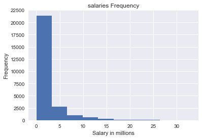

```python
# Plotting Histogram

%matplotlib inline
plt.hist(salariesDF["salary"]/1000000, bins = 10)
plt.ylabel("Frequency")
plt.xlabel("Salary in millions")
plt.title('salaries Frequency')
```

In Histogram above, we can clearly see that most of the salaries are below 2.5 million and there are very few in above 2.5 millon range

Now, i will look into relationship between teamID and salary by finding sum, mean, min and max through them.

```python
# Creating Database

salariesDF_teamID = salariesDF[["teamID","salary"]]

salariesDF_summary_by_teamID = salariesDF_teamID.groupby("teamID").agg([np.sum,np.max,np.min,np.mean])
salariesDF_summary_by_teamID.columns = ["sum", "max", "min", "mean"]
salariesDF_summary_by_teamID.head()
```

| teamID | sum | max | min | mean |
| --- | --- | --- | --- | --- |
| ANA | 468091973 | 13166667 | 150000 | 1.895109e+06 |
| ARI | 1359248291 | 31799030 | 170000 | 2.521796e+06 |
| ATL | 2023226325 | 16061802 | 60000 | 2.211176e+06 |
| BAL | 1907108327 | 21268890 | 60000 | 2.028839e+06 |
| BOS | 2802350096 | 30000000 | 60000 | 2.968591e+06 |

```python
def bargraph(column): # column = sum, max, min, mean
    frequency = salariesDF_summary_by_teamID[column].sort_values(axis=0, ascending = False).head(10)
    objects = frequency.index
    y_pos = np.arange(len(objects))
    plt.bar(y_pos, frequency, align='center')
    plt.xticks(y_pos, objects)
    plt.ylabel('Salary')
    plt.title("Top 10 {} of salaries by teamID".format(column))
    print "Top 10 {} of salaries by teamID".format(column)
    print frequency
    plt.show()
```

```
Top 10 sum of salaries by teamID
teamID
NYA    3496240041
BOS    2802350096
LAN    2453558703
PHI    2153028800
DET    2138358918
NYN    2117310904
ATL    2023226325
SFN    2004454588
TEX    1989872010
CHN    1975712625
Name: sum, dtype: int64
```

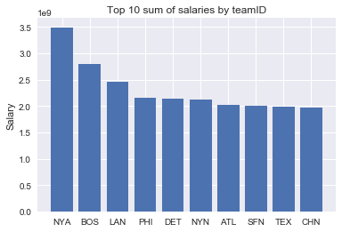

```
Top 10 max of salaries by teamID
teamID
LAD    33000000
NYA    33000000
LAN    32571000
ARI    31799030
BOS    30000000
DET    28000000
NYM    27328046
LAA    26187500
SEA    25857143
NYY    25000000
Name: max, dtype: int64
```

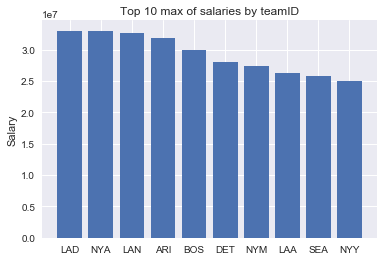

```
Top 10 min of salaries by teamID
teamID
WSN    514400
CHW    513000
NYM    511360
TBR    510000
CHC    508500
SFG    508500
KCR    508450
NYY    507500
STL    507500
LAD    507500
Name: min, dtype: int64
```

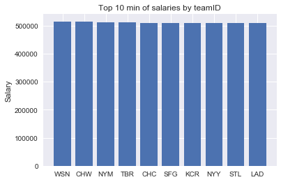

```
Top 10 mean of salaries by teamID
teamID
NYY    7.689579e+06
SFG    6.890151e+06
LAD    6.322525e+06
WSN    5.448179e+06
CHC    5.312678e+06
NYM    4.958857e+06
STL    4.614629e+06
KCR    4.534039e+06
CHW    4.519947e+06
LAA    4.291454e+06
Name: mean, dtype: float64
```

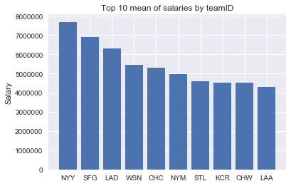

```python
%matplotlib inline
bargraph("sum")
bargraph("max")
bargraph("min")
bargraph("mean")
```

Now i am going to investsigate 2D exploration

Reindexing the salary dataframe with a key value set (year, player ID)

```python
keyValue = ("{}, {}".format(salariesDF["yearID"].iloc[i],salariesDF["playerID"].iloc[i]) for i in range(len(salariesDF)))

salariesDFkv = pd.DataFrame(salariesDF.values, columns = list(salariesDF.columns.values), index = list(keyValue))
salariesDFkv
```

|  | yearID | teamID | lgID | playerID | salary |
| --- | --- | --- | --- | --- | --- |
| 1985, barkele01 | 1985 | ATL | NL | barkele01 | 870000 |
| 1985, bedrost01 | 1985 | ATL | NL | bedrost01 | 550000 |
| 1985, benedbr01 | 1985 | ATL | NL | benedbr01 | 545000 |
| 1985, campri01 | 1985 | ATL | NL | campri01 | 633333 |
| 1985, ceronri01 | 1985 | ATL | NL | ceronri01 | 625000 |
| 1985, chambch01 | 1985 | ATL | NL | chambch01 | 800000 |
| 1985, dedmoje01 | 1985 | ATL | NL | dedmoje01 | 150000 |
| 1985, forstte01 | 1985 | ATL | NL | forstte01 | 483333 |
| 1985, garbege01 | 1985 | ATL | NL | garbege01 | 772000 |
| 1985, harpete01 | 1985 | ATL | NL | harpete01 | 250000 |
| 1985, hornebo01 | 1985 | ATL | NL | hornebo01 | 1500000 |
| 1985, hubbagl01 | 1985 | ATL | NL | hubbagl01 | 455000 |
| 1985, mahleri01 | 1985 | ATL | NL | mahleri01 | 407500 |
| 1985, mcmurcr01 | 1985 | ATL | NL | mcmurcr01 | 275000 |
| 1985, mumphje01 | 1985 | ATL | NL | mumphje01 | 775000 |
| 1985, murphda05 | 1985 | ATL | NL | murphda05 | 1625000 |
| 1985, oberkke01 | 1985 | ATL | NL | oberkke01 | 616667 |
| 1985, perezpa01 | 1985 | ATL | NL | perezpa01 | 450000 |
| 1985, perryge01 | 1985 | ATL | NL | perryge01 | 120000 |
| 1985, ramirra01 | 1985 | ATL | NL | ramirra01 | 750000 |
| 1985, suttebr01 | 1985 | ATL | NL | suttebr01 | 1354167 |
| 1985, washicl01 | 1985 | ATL | NL | washicl01 | 800000 |
| 1985, boddimi01 | 1985 | BAL | AL | boddimi01 | 625000 |
| 1985, dauerri01 | 1985 | BAL | AL | dauerri01 | 480000 |
| 1985, davisst02 | 1985 | BAL | AL | davisst02 | 437500 |
| 1985, dempsri01 | 1985 | BAL | AL | dempsri01 | 512500 |
| 1985, dwyerji01 | 1985 | BAL | AL | dwyerji01 | 375000 |
| 1985, flanami01 | 1985 | BAL | AL | flanami01 | 641667 |
| 1985, fordda01 | 1985 | BAL | AL | fordda01 | 450000 |
| 1985, grosswa01 | 1985 | BAL | AL | grosswa01 | 483333 |
| ... | ... | ... | ... | ... | ... |
| 2016, stromma01 | 2016 | TOR | AL | stromma01 | 515900 |
| 2016, tholejo01 | 2016 | TOR | AL | tholejo01 | 800000 |
| 2016, travide01 | 2016 | TOR | AL | travide01 | 511200 |
| 2016, tulowtr01 | 2016 | TOR | AL | tulowtr01 | 20000000 |
| 2016, barreaa01 | 2016 | WSN | NL | barreaa01 | 519400 |
| 2016, belisma01 | 2016 | WSN | NL | belisma01 | 1250000 |
| 2016, drewst01 | 2016 | WSN | NL | drewst01 | 3000000 |
| 2016, espinda01 | 2016 | WSN | NL | espinda01 | 2875000 |
| 2016, gonzagi01 | 2016 | WSN | NL | gonzagi01 | 12100000 |
| 2016, harpebr03 | 2016 | WSN | NL | harpebr03 | 5000000 |
| 2016, heisech01 | 2016 | WSN | NL | heisech01 | 1250000 |
| 2016, kellesh01 | 2016 | WSN | NL | kellesh01 | 4000000 |
| 2016, lobatjo01 | 2016 | WSN | NL | lobatjo01 | 1387500 |
| 2016, murphda08 | 2016 | WSN | NL | murphda08 | 8000000 |
| 2016, papeljo01 | 2016 | WSN | NL | papeljo01 | 10936574 |
| 2016, perezol01 | 2016 | WSN | NL | perezol01 | 3000000 |
| 2016, petityu01 | 2016 | WSN | NL | petityu01 | 2500000 |
| 2016, ramoswi01 | 2016 | WSN | NL | ramoswi01 | 5350000 |
| 2016, rendoan01 | 2016 | WSN | NL | rendoan01 | 2800000 |
| 2016, reverbe01 | 2016 | WSN | NL | reverbe01 | 6250000 |
| 2016, riverfe01 | 2016 | WSN | NL | riverfe01 | 516100 |
| 2016, roarkta01 | 2016 | WSN | NL | roarkta01 | 543400 |
| 2016, robincl01 | 2016 | WSN | NL | robincl01 | 534900 |
| 2016, rossjo01 | 2016 | WSN | NL | rossjo01 | 514400 |
| 2016, scherma01 | 2016 | WSN | NL | scherma01 | 22142857 |
| 2016, strasst01 | 2016 | WSN | NL | strasst01 | 10400000 |
| 2016, taylomi02 | 2016 | WSN | NL | taylomi02 | 524000 |
| 2016, treinbl01 | 2016 | WSN | NL | treinbl01 | 524900 |
| 2016, werthja01 | 2016 | WSN | NL | werthja01 | 21733615 |
| 2016, zimmery01 | 2016 | WSN | NL | zimmery01 | 14000000 |

26426 rows × 5 columns

Reindexing the Players dataframe with the key value(year, player ID).

```python
keyValue = ("{}, {}".format(playersDF["yearID"].iloc[i],playersDF["playerID"].iloc[i]) for i in range(len(playersDF)))

playersDFkv = pd.DataFrame(playersDF.values, columns = list(playersDF.columns.values), index = list(keyValue))
playersDFkv.head()
```

|  | awardID | yearID | lgID | playerID | pointsWon | pointsMax | votesFirst |
| --- | --- | --- | --- | --- | --- | --- | --- |
| 1956, fordwh01 | Cy Young | 1956 | ML | fordwh01 | 1 | 16 | 1 |
| 1956, maglisa01 | Cy Young | 1956 | ML | maglisa01 | 4 | 16 | 4 |
| 1956, newcodo01 | Cy Young | 1956 | ML | newcodo01 | 10 | 16 | 10 |
| 1956, spahnwa01 | Cy Young | 1956 | ML | spahnwa01 | 1 | 16 | 1 |
| 1957, donovdi01 | Cy Young | 1957 | ML | donovdi01 | 1 | 16 | 1 |

Merging both salary and players dataframe

```python
salaryPlayerDF = pd.merge(salariesDFkv, playersDFkv, how = "inner")
salaryPlayerDF.head()
```

|  | yearID | teamID | lgID | playerID | salary | awardID | pointsWon | pointsMax | votesFirst |
| --- | --- | --- | --- | --- | --- | --- | --- | --- | --- |
| 0 | 1985 | ATL | NL | murphda05 | 1625000 | MVP | 63 | 336 | 0 |
| 1 | 1985 | BAL | AL | murraed02 | 1472819 | MVP | 130 | 392 | 0 |
| 2 | 1985 | BAL | AL | ripkeca01 | 800000 | MVP | 9 | 392 | 0 |
| 3 | 1985 | BOS | AL | boggswa01 | 1000000 | MVP | 159 | 392 | 0 |
| 4 | 1985 | BOS | AL | gedmari01 | 477500 | MVP | 1 | 392 | 0 |

```python
# Standardizing
def standard(sr):
    return (sr - sr.mean())/sr.std(ddof=0)

salaryPlayerDF = salaryPlayerDF[["pointsWon", "salary"]]
```

[figure not shown]

```python
# Creating scatter plot for better understanding

%matplotlib inline
plt.scatter(salaryPlayerDF["pointsWon"], salaryPlayerDF["salary"])
plt.title('Scatter Plot')
plt.xlabel('salaries of Players')
plt.ylabel('Points Won')
plt.show()
```

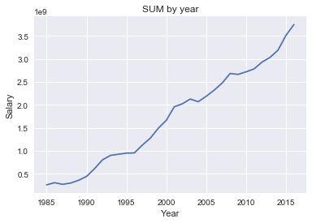

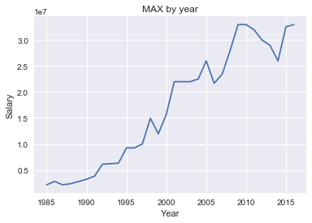

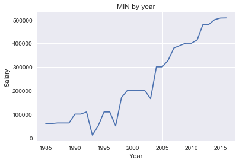

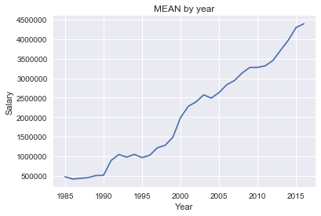

```python
salariesDF_by_year = salariesDF[["yearID","salary"]].groupby("yearID").agg([np.sum,np.max,np.min,np.mean])
salariesDF_by_year.columns = ["sum", "max", "min", "mean"]


%matplotlib inline
PlotList = ["sum", "max", "min", "mean"]

for item in PlotList:
    plt.title('{} by year'.format(item.upper()))
    plt.xlabel('Year')
    plt.ylabel('Salary')

    plt.plot(salariesDF_by_year.index, salariesDF_by_year[item])
    plt.show()
```

Since all the graphs are increasing as the year progress,but in maximum graph there is a fall in the graph near year 2014.

```python
# Invesigating Maximum Graph

maxSalaryByYear = salariesDF_by_year["max"].argmax()

print "\nMaximum salary in {}, $ {}\n".format(maxSalaryByYear, salariesDF_by_year["max"].loc[maxSalaryByYear])
```

```
Maximum salary in 2009, $ 33000000
```

```python
maxDFyear = salariesDF[salariesDF["yearID"]==2009]
maxPlayer2009 = maxDFyear[maxDFyear["salary"] == salariesDF_by_year["max"].loc[maxSalaryByYear]]
maxPlayerID = maxPlayer2009["playerID"].values[0]
print maxPlayerID
print "Detailed information of the player"
print maxPlayer2009
```

```
rodrial01
Detailed information of the player
       yearID teamID lgID   playerID    salary
20286    2009    NYA   AL  rodrial01  33000000
```

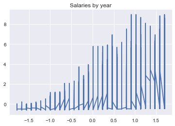

```python
# Reationship between year and salary
# Histogram

salaryYearDF = salariesDF[["yearID","salary"]]
standardizedDF = salaryYearDF.apply(standard)


%matplotlib inline

plt.title("Salaries by year")

plt.plot(standardizedDF["yearID"], standardizedDF["salary"])
```

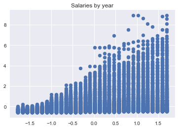

```python
# Reationship between year and salary
# Histogram

salaryYearDF = salariesDF[["yearID","salary"]]
standardizedDF = salaryYearDF.apply(standard)

%matplotlib inline
plt.scatter(standardizedDF["yearID"], standardizedDF["salary"])
plt.title("Salaries by year")
```

```python
# Correlation

correlation = (standardizedDF["yearID"] * standardizedDF["salary"]).mean()
print "Correlation between salaries and year:",correlation
```

```
Correlation between salaries and year: 0.351731069136
```

Thus there is a positive correlation between years and salaries of the players

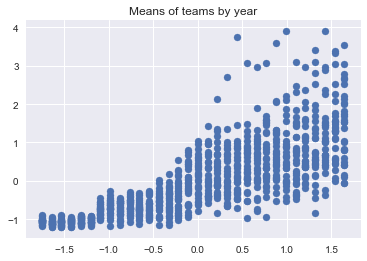

```python
# Relatonship between year and salary
# Vetiorized operations

salaryYearDF = salariesDF[["yearID","teamID","salary"]].groupby(["yearID","teamID"]).mean()

x = salaryYearDF.index.values
x = np.array(map(lambda x: int(x[0]), x))

y = salaryYearDF.values.reshape(1, len(salaryYearDF.values))[0]

x = (x - x.mean()) / x.std()
y = (y - y.mean()) / y.std()


%matplotlib inline
plt.scatter(x,y)
plt.title("Means of teams by year")
```

The above graph is showing the means of teams salries, not the salaries of the players. Here we can see that the minimum salaries is increasing as the year progress.

```python
correlation = (x * y).mean()
print "Correlation between mean salaries by team and year:", correlation
```

```
Correlation between mean salaries by team and year: 0.783218833901
```

# CONCLUSION

1) Since the data volume of martija02 was very low, i have left that player from my dataset.

3) I found the data appropriate to find answers of my investigaion.

4) There are many tools such s 'R' and 'SQL' could be used to perfoem statistical test to find the exploration of this data.